# Did Medicaid Expansion Affect Drug Overdose Deaths in Appalachia?

2022-12-06

## Research Motivations

- Deaths due to drug overdose are a pressing problem facing United States policymakers and society at large, with reportedly more than 932,000 people dying due to overdose since 1999 ([CDC, 2022](https://www.cdc.gov/drugoverdose/deaths/index.html)).
- Rates of overdose deaths increased in nearly every US state from 2013-2017, with particularly severe incidence in the Appalachian region ([CDC, 2020](https://www.cdc.gov/drugoverdose/deaths/2013-2017-increase.html); [CDC, 2021](https://www.cdc.gov/drugoverdose/deaths/2014.html)).
- The increase in deaths is driven primarily by the ongoing US opioid crisis, with the vast majority (>80%) of overdose deaths associated with opioid use ([CDC, 2022](https://www.cdc.gov/drugoverdose/deaths/index.html)).
- **In this context, we aim to assess whether expansion of the social safety net through government policy can be causally linked to reductions in drug overdose death rates.**

## Policy Background

- The Affordable Care Act (ACA) was passed by the United States Congress and signed into law by President Barack Obama in 2010, drastically changing the policy landscape for health care in the United States.
- **Among the major provisions in the ACA was expanded eligibility for Medicaid (i.e., “Medicaid Expansion”), which allowed states the option to raise the income-eligibility threshold to 138% of the federal poverty level ([KFF, 2022](https://www.kff.org/medicaid/issue-brief/status-of-state-medicaid-expansion-decisions-interactive-map/)).**
- Of the **13 states** whose boundaries overlap with the broad geographical definition of Appalachia, **five states** (Kentucky, Maryland, New York, Ohio, and West Virginia) passed legislation mandating the expansion of Medicaid as of January 1st, 2014 ([KFF, 2022](https://www.kff.org/medicaid/issue-brief/status-of-state-medicaid-expansion-decisions-interactive-map/)). **Two additional states**, Pennsylvania and Virginia, would later expand Medicaid, with the former in 2015 and the latter in 2019.
- **Six states** (Alabama, Georgia, Mississippi, North Carolina, South Carolina, and Tennessee) have not expanded Medicaid to-date.

## Policy Background

- In total, 210 Appalachian counties are located in expansion states and 213 Appalachian counties are located in non-expansion states.

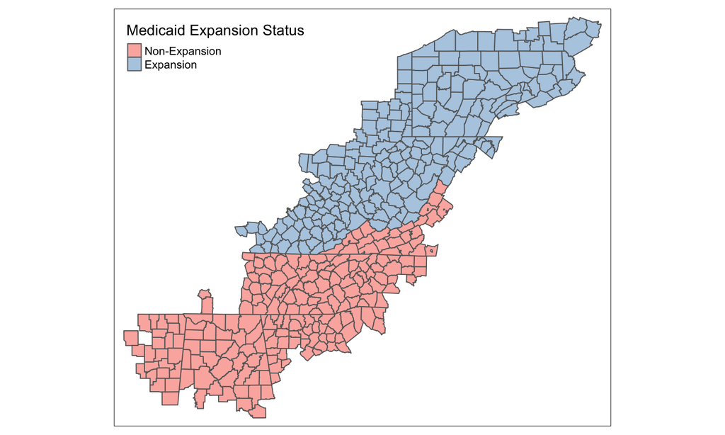

## Research Hypothesis

- In our study, we identify the discrepancy in Medicaid expansion as a policy “treatment” (i.e., “differential exposure between entities over time”) affecting drug overdose incidence in Appalachian communities.
- Our *hypothesized* causal mechanism is that expanded Medicaid eligibility allowed for greater access to low-cost health care among Appalachian counties in expansion states, therefore enabling people struggling with drug addiction to receive treatment, *reducing* overall deaths from drug overdose in these areas.
- Existing literature has also examined the counter-hypothesis that Medicaid expansion may have actually *increased* drug overdose rates by increasing access to prescription opioids. [Swartz and Beltran (2019)](https://onlinelibrary.wiley.com/doi/epdf/10.1111/add.14741) find that, while Medicaid expansion did increase prescription opioid availability, there was no accompanying increase in overdose mortality. [Venkataramani and Chatterjee (2018)](https://www.ncbi.nlm.nih.gov/pmc/articles/PMC6318168/) examine early 2000s Medicaid expansion in Arizona, Maine, and New York, and find that expansion did in fact *decrease* overdose death rates relative to neighboring non-expansion states.

## Data Description

- Our data is a county-year panel dataset, comprised of Appalachian counties over the period 2011-2019. For analysis, we restrict the panel to the three years prior to Medicaid expansion and the five years after, resulting in a final dataset of 3384 observations.
- Data on drug overdose death rates (i.e., deaths per 100,000 residents) comes from estimates modeled by the National Center for Health Statistics (NCHS), which are available at the county-level for the period 2003-2020.
- County-level demographic covariates are taken from the US Census Bureau American Community Survey (ACS).

| COUNTY | Year | FIPS | STATE | medicaid_expansion | expansion_date | treat |
| --- | --- | --- | --- | --- | --- | --- |
| Adair | 2011 | 21001 | Kentucky | Expansion | 2014-01-01 | 0 |
| Adair | 2012 | 21001 | Kentucky | Expansion | 2014-01-01 | 0 |
| Adair | 2013 | 21001 | Kentucky | Expansion | 2014-01-01 | 0 |
| Adair | 2014 | 21001 | Kentucky | Expansion | 2014-01-01 | 1 |

## Data Description

Difference-in-means during year of Medicaid expansion by county expansion status

|  | Non-Expansion (N=213) Mean | Non-Expansion (N=213) Std. Dev. | Expansion (N=210) Mean | Expansion (N=210) Std. Dev. | Diff. in Means | p |
| --- | --- | --- | --- | --- | --- | --- |
| Median Income ($) | 39623.55 | 7786.51 | 40245.98 | 8272.65 | 622.43 | 0.43 |
| Median Age | 41.54 | 4.18 | 42.05 | 3.26 | 0.50 | 0.17 |
| Male Share | 49.19 | 1.35 | 49.97 | 2.32 | 0.78 | <0.001 |
| Black Share | 10.62 | 14.52 | 2.49 | 3.05 | -8.14 | <0.001 |
| Hispanic Share | 4.09 | 4.14 | 1.60 | 1.66 | -2.48 | <0.001 |
| White Share | 82.72 | 14.76 | 93.89 | 4.81 | 11.17 | <0.001 |
| Asian Share | 0.71 | 1.12 | 0.57 | 0.94 | -0.14 | 0.16 |

Note: Observations are weighted by the population in each county.

## Exploratory Analaysis

Examining overdose death rates over time for expansion and non-expansion counties in Appalachia, it appears that Medicaid expansion had a *positive* effect on overdose death rates, contradicting the direction of our hypothesized causal effect.

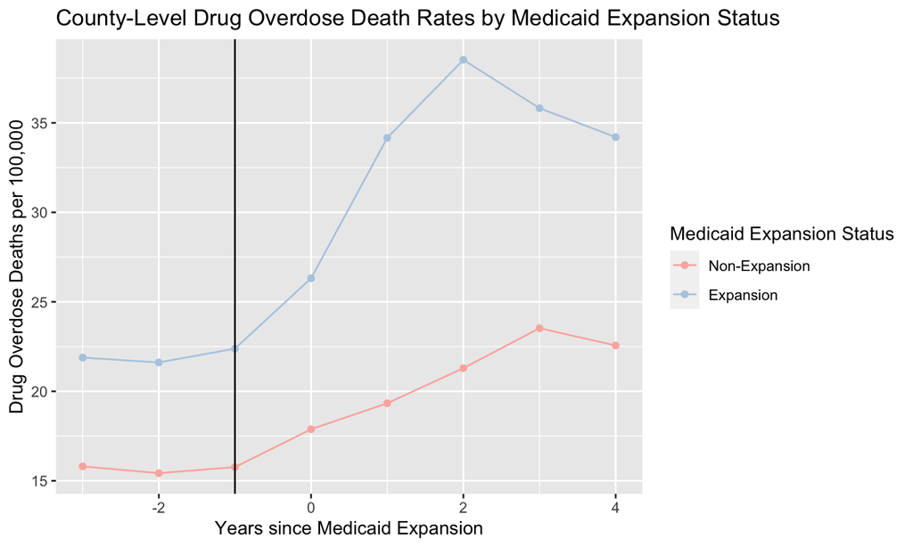

## Empirical Strategy

To evaluate the effect of Medicaid expansion on drug overdose deaths in Appalachian counties, we estimate the following “differences-in-differences” specification:

\[Overdose~Death~Rate_{it} = \beta Medicaid~Expansion_{it} + \textbf{X}_{it} \gamma + \nu_{i} + \tau_{t} + \varepsilon_{it}\]

where \(Overdose~Death~Rate_{it}\) is deaths attributed to drug overdose per 100,000 county residents for county \(i\) at time \(t\), \(Medicaid~Expansion_{it}\) indicates “treatment” status (i.e., enactment of Medicaid expansion) for a county-year, \(\textbf{X}_{it}\) is a vector of time varying controls (e.g., median income, median age, male population share, racial composition) for potential county-level determinants of overdose death rates outside of our policy variation of interest.

Additionally, we include an array of county fixed effects, \(\nu_{i}\), that control for unobserved time-invariant factors specific to individual counties. We further include \(\tau_{t}\), year fixed effects, to control for unobserved county-invariant factors that might have changed between each year included in our panel. Finally, \(\varepsilon_{it}\) is the idiosyncratic error term.

## Estimation Results

We test two model specifications to estimate difference-in-difference effects. The first considers effects up to two years following Medicaid expansion, while the second considers effects up to five years following Medicaid expansion.

Effect of Medicaid Expansion on Drug Overdose Death Rates

|  | Two Years Post-Expansion | Five Years Post-Expansion |
| --- | --- | --- |
| Medicaid Expansion | 4.0803*** | 7.8280*** |
|  | (0.6920) | (1.1228) |
| Median Income ($) | −0.0004*** | −0.0004*** |
|  | (0.0001) | (0.0001) |
| Median Age | 0.0365 | 0.0113 |
|  | (0.2306) | (0.2591) |
| Male Population Share (0-100) | 0.0000 | 0.0001* |
|  | (0.0001) | (0.0000) |
| Black Population Share | −0.0001* | −0.0001** |
|  | (0.0001) | (0.0001) |
| Hispanic Population Share | −0.0002 | −0.0001 |
|  | (0.0002) | (0.0001) |
| Asian Population Share | 0.0009*** | 0.0005 |
|  | (0.0003) | (0.0003) |
| N | 2115 | 3384 |
| R-squared | 0.779 | 0.766 |
| Adj. R-squared | 0.738 | 0.741 |
| County FEs | X | X |
| Year FEs | X | X |

* p < 0.1, ** p < 0.05, *** p < 0.01  
Robust standard errors clustered by county are shown in parentheses. Observations are weighted by the population in each county.

## Discussion

- Our estimates provide significant evidence for the conclusion that Medicaid expansion in Appalachian states had the unintended consequence of *increasing* deaths from drug overdose. A possible mechanism for this result is increased access to prescription opioids.
- Our findings differ from previous studies on the effect of Medicaid expansion on overdose deaths. However, one of these studies [Swartz and Beltran (2019)](https://onlinelibrary.wiley.com/doi/epdf/10.1111/add.14741), did find that expansion increased the supply of prescription opioids and that there could be a lagged increase in overdose deaths.
- Key limitations include potential OVB due to county-year variation in number of Substance Use Disorder (SUD) treatment facilities and lack of external validity outside of Appalachia. The latter limitation could explain why our results differ from previous studies.